This Jupyter Notebook contains starter cells to organize the slide deck deliverable. These cells provide an example of how the slide deck should be organized, including pre-set slideshow settings.

<a id ='T3'> </a>

# Exploratory Visualization

<a id ='T3_1'> </a>

## Univariate Exploration

**How long are people riding these bikes?**

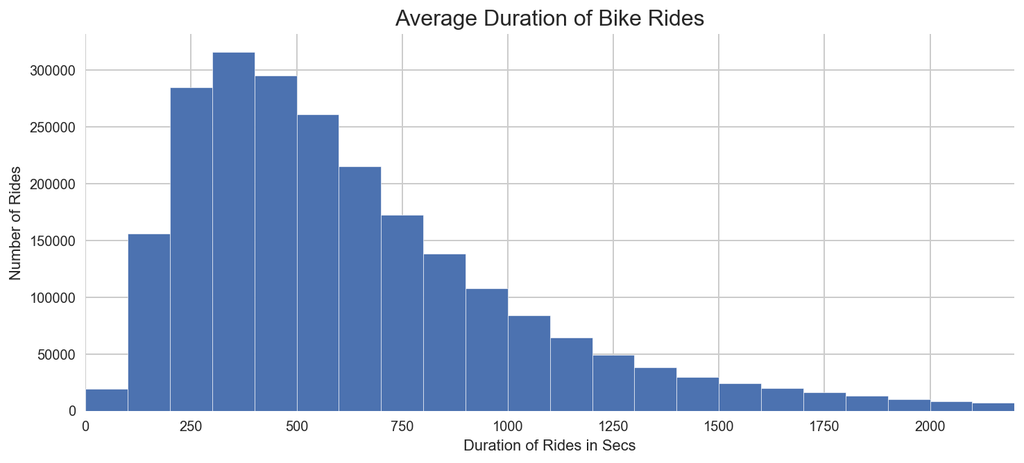

```python
#Visualizing the data in a histogram
plt.figure(figsize= (12,5))
duration_bins = np.arange(0, df['duration_sec'].max() + 200, 100)
plt.hist(data = df, x = 'duration_sec', bins = duration_bins);

plt.xlim(0, 2200);
plt.style.use('seaborn')
plt.title('Average Duration of Bike Rides', fontsize = 16);
plt.xlabel('Duration of Rides in Secs');
plt.ylabel('Number of Rides');
plt.style.use('seaborn');
```

<a id ='T3_2'> </a>

## Bivariate Exploration

**When are most trips taken in terms of day of the week?**

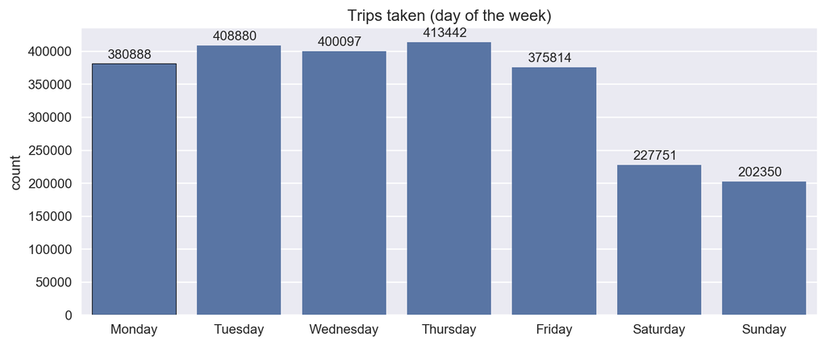

```python
fig, axes = plt.subplots(figsize = (10,4), dpi = 100)
sns.barplot(data = df_weekday, x= 'index',y='count', color= sns.color_palette()[0],lw = 0.5, edgecolor = "black")
cur_axes = plt.gca()
cur_axes.axes.get_yaxis()
cur_axes.axes.get_xaxis().set_label_text('')
sns.despine(fig, left = True)

for p in axes.patches:
    axes.annotate('{:.0f}'.format(p.get_height()), (p.get_x()+0.15, p.get_height()+ 8000))

plt.title('Trips taken (day of the week)');
```

**When are most trips taken in terms of time of the day?**

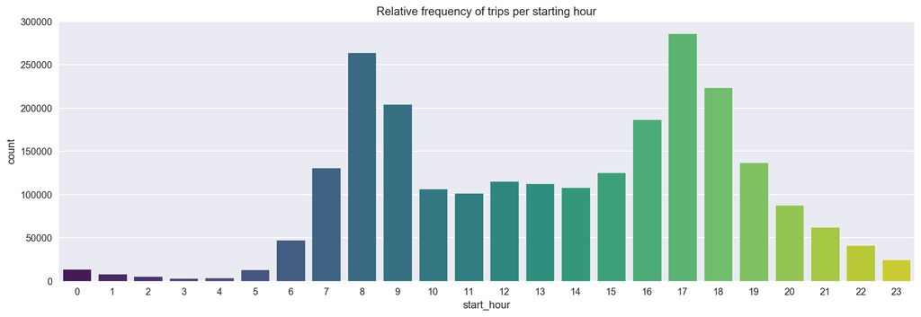

```python
fig, ax = plt.subplots(figsize = (16,5))
sns.countplot(x = "start_hour", data = df, palette = "viridis")
plt.title("Relative frequency of trips per starting hour");
```

The most frequent starting hours are at commute peak time 8 and at 17. Lets see if this pattern is specially for weekday.

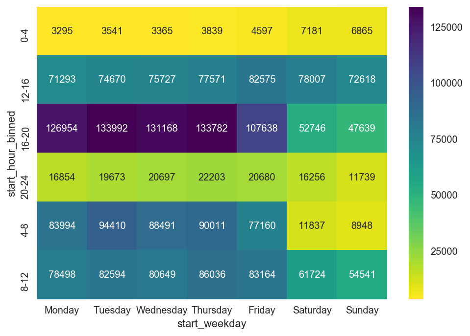

```python
sns.heatmap(heatmap_df,
            # add annotation
            annot = True,
            # all the counts are listed as decimal values can use fmt ='.0f' if we have any cells with no counts
            fmt = 'd', cmap ='viridis_r');
```

- We can see that oveall people turns to take rides more on Weekday commute time (16-20pm and 8:12am). This pattern is not that obvious during weekend.

<a id ='T3_3'> </a>

## Multivariate Exploration

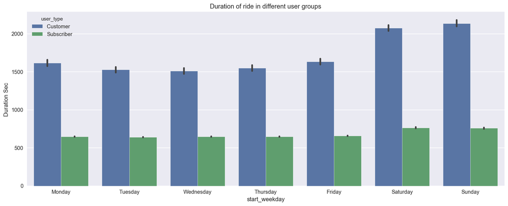

```python
plt.figure(figsize =(16,6))
base_color = sns.color_palette()[0]
sns.barplot(data= df, x ='start_weekday', y='duration_sec', hue ='user_type' )
plt.ylabel("Duration Sec ")
plt.title("Duration of ride in different user groups");
```

- We can see that most compared to non-subscribed customer group, the subscribed customer group turns to have ride in slight difference of each day of week and the average ride time is lower.

**Can we find any patterns in terms of month?**

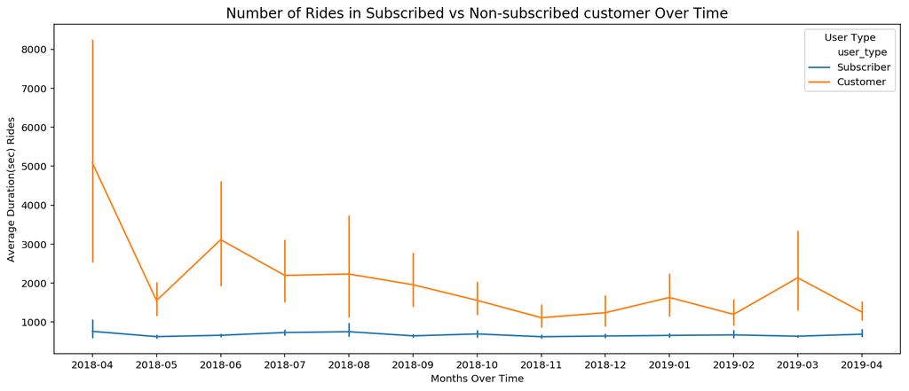

```python
plt.figure(figsize=(15,6))
sns.lineplot(data = df_sample, x = 'year_month', y = 'duration_sec', markers=True, hue = 'user_type',err_style="bars");
plt.title('Number of Rides in Subscribed vs Non-subscribed customer Over Time', fontsize = 14)
plt.legend(title = 'User Type')
plt.xlabel('Months Over Time')
plt.ylabel('Average Duration(sec) Rides');
```

We can see that for the subscriber, the the average ride time is more stable over time while the people turn to ride less on certain months, this may due to the weather issue.